# Homework 1

Scott Girten

All homework will be submitted via R Markdown files.

### Question 1

Complete problem 3.5 (page 71) in the text. The two requested hypothesis tests should follow the format below:

- Define the parameters of interest and state the hypotheses to be tested.
- Define the test statistic used to test the claim.
- Simulate the null distribution of the test statistic, including a histogram of the distribution with the observed test statistic identified.
- Caclulate the p-value of the test.
- Report a conclusion for the test.

$\underline{\textbf{Part A}}$

> $\mu_a$ = mean delay time for American Airlines

> $\mu_u$ = mean delay time for United Airlines

> $H_o : \mu_a = \mu_u$

> $H_a : \mu_a \ne \mu_u$

**Test Statistic:** if the difference in mean delay times for American Airlines and United Airlines is statistically significant, the test statistic $T(X) = \lvert\bar{X}_a - \bar{X}_u\rvert$ can be used.

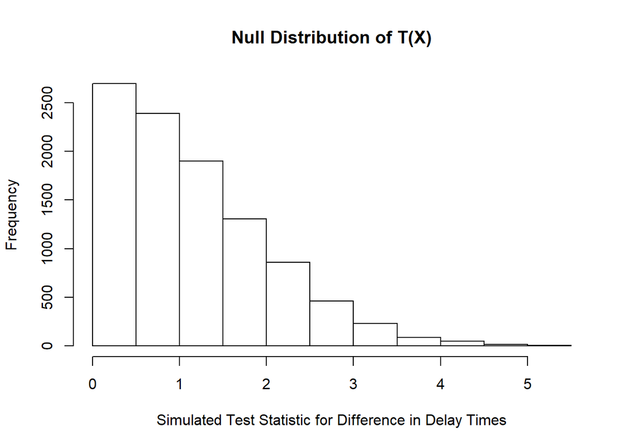

```r
# Combine American and United delays into one vector
delays_total = c(United_delays, American_delays)

# Create a storage vector for the simulated differences
delays_simulated_ts = numeric(9999)

for (i in 1:9999){
  # Create vector of length of delays_total and the number of samples is length of United_delays vector
  index = sample(length(delays_total), length(United_delays), replace = FALSE)
  delays_simulated_ts[i] = abs(mean(delays_total[index]) - mean(delays_total[-index]))
}

hist(delays_simulated_ts, main = "Null Distribution of T(X)", xlab = "Simulated Test Statistic for Difference in Delay Times")
```

**p-value Calculation**

[figure not shown]

```r
# Calculate observed test statistic
obs_ts = abs(mean(United_delays) - mean(American_delays))

hist(delays_simulated_ts, main = "Null Distribution of T(X)", xlab = "Simulated Test Statistic for Difference in Delay Times")

# Vertical line representing the observed teset statistic
abline(v = obs_ts, col="orange", lwd = 3)
```

The p-value for $T(X)$ is 10^{-4}

**Conclusion:** Due to a small p-value of the observed test statistic, there is evidence to conclude that there is a statistical difference in the mean delay times between American and United Airlines.

$\underline{\textbf{Part B}}$

> $\mu_M$ = mean delay time for May

> $\mu_J$ = mean delay time for June

> $H_o: \mu_M = \mu_J$

> $H_a: \mu_M \ne \mu_J$

**Test Statistic:** if the differnce in mean delay time between May and June is statistically significant, the test statistic $T(X) = \lvert\bar{X}_M - \bar{X}_J\rvert$ can be used.

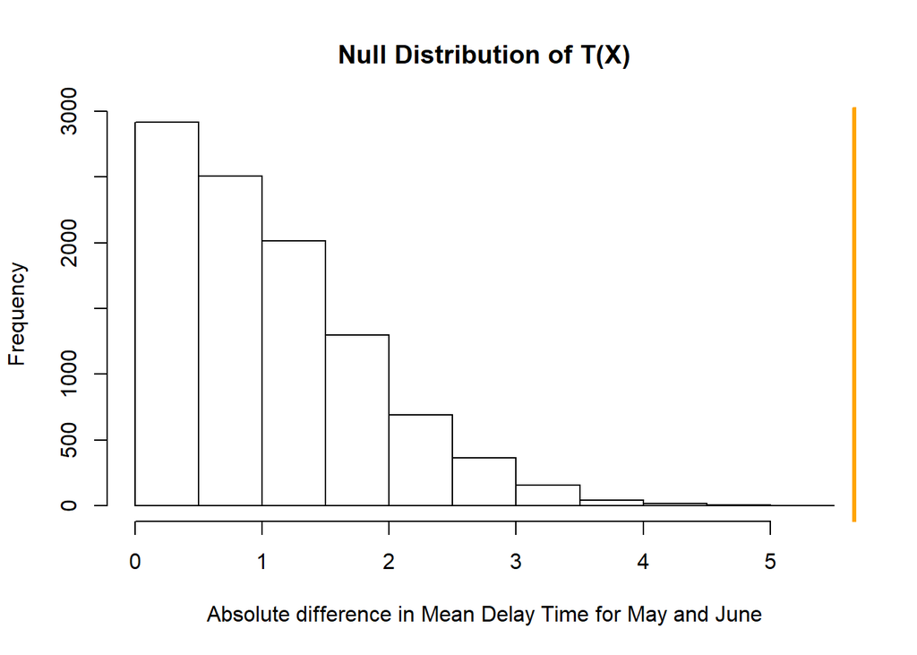

```r
# Combine May and June delays into one vector
month_delays = c(May_delays, June_delays)

month_sim_ts = numeric(9999)
 for (i in 1:9999){
   index = sample(length(month_delays), length(May_delays), replace=FALSE)
   month_sim_ts[i] = abs(mean(month_delays[index]) - mean(month_delays[-index]))
 }

month_obs_ts = abs(mean(May_delays) - mean(June_delays))

hist(month_sim_ts, main = "Null Distribution of T(X)", xlab ="Absolute difference in Mean Delay Time for May and June")
abline(v = month_obs_ts, col="orange", lwd = 3)
```

```r
month_pvalue = (sum(month_sim_ts >= month_obs_ts) + 1) / 10000
```

The p-value is 10^{-4}

**Conclusion:** Due to a small p-value of the observed test statistic, there is evidence of a statistically significant difference in the mean delay times for May and June.

### Question 2

Complete problem 3.7 (page 71). The problem asks you to repeat part a of question 3.5 using 3 different test statistics. Please make sure the caclulation of the 3 test statistics all occurs within the same FOR loop.

**Code to conduct the 3 tests and calculate the p-values**

```r
# 3 observed test statistics
mean_UA_obs = mean(United_delays)
sum_UA_obs = sum(United_delays)
mean_diff_obs = mean(United_delays) - mean(American_delays)

# 3 vectors to store simulations
sum_UA_ts = numeric(9999)
mean_UA_ts = numeric(9999)
mean_diff_ts = numeric(9999)

for (i in 1:9999){
  index = sample(length(delays_total), length(United_delays), replace = F)
  sum_UA_ts[i] = sum(delays_total[index])
  mean_UA_ts[i] = mean(delays_total[index])
  mean_diff_ts[i] = mean(delays_total[index]) - mean(delays_total[-index])
}

# p-value calculations
sum_pval = (sum(sum_UA_ts >= sum_UA_obs) + 1) / 10000
mean_pval = (sum(mean_UA_ts >= mean_UA_obs) + 1) / 10000
mean_diff_pval = (sum(mean_diff_ts >= mean_diff_obs) + 1) / 10000
```

| Statistic | p-value |
| --- | --- |
| Mean | 10^{-4} |
| Sum | 10^{-4} |
| mean Difference | 10^{-4} |

**Observation:** The p-values for all 3 statistics have the same value. My assumpiton is that since all 3 statistics were simulated in the same for loop they will then have the same p-values.

### Question 3

Suppose a permutation test was conducted on this data to determine if there is a difference in the mean taxi fare for the two payment methods.

- If the *exact* null distribution were constructed, how many unique resamples exist?
  - The exact null distribution would contain $\binom{150}{78}$ resamples.
- With a much larger pool of resamples, let’s investigate the effect number of resamples has on the mean and varaibility of p-values from the permutation test. Write code to generate output that will allow the table below to be filled in based on the simulation of 1000 p-values (note to save computing time, I’ve provided the values for 20,000 resamples):

```r
total_payments = c(cash, credit)

# Create vecotos for each p-value simulation
one_K_pval = numeric(1000)
five_K_pval = numeric(1000)
ten_K_pval = numeric(1000)
fifteen_K_pval = numeric(1000)

# Simulation loop
for (i in 1:1000){

  # Create dataframe for each number of resamples
  one_K_resamples = replicate(1000, sample(total_payments, length(total_payments), replace = F))
  five_K_resamples = replicate(5000, sample(total_payments, length(total_payments), replace = F))
  ten_K_resamples = replicate(10000, sample(total_payments, length(total_payments), replace = F))
  fifteen_K_resamples = replicate(15000, sample(total_payments, length(total_payments), replace = F))

  # Test statistic for each number of resamples
  one_K_sim_ts = abs(apply(one_K_resamples[1:78,], 2, mean) - apply(one_K_resamples[79:150,], 2, mean))
  five_K_sim_ts = abs(apply(five_K_resamples[1:78,], 2, mean) - apply(five_K_resamples[79:150,], 2, mean))
  ten_K_sim_ts = abs(apply(ten_K_resamples[1:78,], 2, mean) - apply(ten_K_resamples[79:150,], 2, mean))
  fifteen_K_sim_ts = abs(apply(fifteen_K_resamples[1:78,], 2, mean) - apply(fifteen_K_resamples[79:150,],   2, mean))

  # Observed test statistic
  taxi_obs_ts = abs(mean(cash) - mean(credit))

  # P-value vector for each number of resamples
  one_K_pval[i] = (sum(one_K_sim_ts >= taxi_obs_ts) + 1) / 1000
  five_K_pval[i] = (sum(five_K_sim_ts >= taxi_obs_ts) + 1) / 5000
  ten_K_pval[i] =  (sum(ten_K_sim_ts >= taxi_obs_ts) + 1) / 10000
  fifteen_K_pval[i] = (sum(fifteen_K_sim_ts >= taxi_obs_ts) + 1) / 15000
}

# Calculate mean and standard deviation for each vector of p-values
one_K_mean = mean(one_K_pval)
five_K_mean = mean(five_K_pval)
ten_K_mean = mean(ten_K_pval)
fifteen_K_mean = mean(fifteen_K_pval)

# Calculate the standard deviation for each vector of p-values
one_K_sd = sd(one_K_pval)
five_K_sd = sd(five_K_pval)
ten_K_sd = sd(ten_K_pval)
fifteen_K_sd = sd(fifteen_K_pval)
```

| Number of Resamples | Mean of the p-values | Std Dev of the p-values |
| --- | --- | --- |
| 1000 | 0.884562 | 0.0101885 |
| 5000 | 0.8839104 | 0.0044428 |
| 10,000 | 0.88376 | 0.003171 |
| 15,000 | 0.8838383 | 0.0026275 |
| 20,000 | 0.8837033 | 0.002207726 |

- Breifly comment on the pattern observed in the means and standard deviations of the p-values.
  - The means of the p-values are approximately the same. The standard deviations of the p-values becomes smaller as the number of resamples increases, leading to less variabiity of the p-value.